# H06: Day type, exercise, sleep, and personal light exposure

Associations with mean hourly melanopic equivalent daylight illuminance among observed hours that met support criteria

Last modified:

August 11, 2026

## Scientific question

The preregistered hypothesis was:

> **H6: Day type, daily exercise, and sleep variables predict daily light exposure metrics.**

The main H06 analysis deliberately narrows that broad question to the zero-aware geometric mean of melanopic equivalent daylight illuminance (melEDI) in each observed one-hour interval that met the support criteria. It asks whether estimated mean hourly near-eye melEDI differs for free versus work days, active versus sedentary day status, and per one additional hour of previous sleep. It averages over retained hours rather than estimating daily light-exposure metrics. Time of day is examined separately and exploratorily. Near-eye measurements are primary; chest measurements provide complementary, non-ocular evidence. Neither position is a direct retinal measure.

The complementary participant-day analysis, which treats one calendar day from one participant as the analytical unit, addresses daily light-exposure metrics. It is complementary evidence, while this hourly report remains the main H06 analysis. The two reports answer related but different questions, so their estimates are not interchangeable.

How the hourly H06 analysis was prepared traces the inputs, fitted samples, formulas, model checks, sensitivity analyses, and source data underlying this report.

**NoteAnswer in brief**

- **Primary result.** After false-discovery-rate adjustment, activity status (**FDR-adjusted p < 0.001**) and day type (**FDR-adjusted p = 0.004**) met the adjusted 0.050 threshold. Previous sleep did not (FDR-adjusted p = 0.745).
- **Qualification.** The day-type association is site- and model-dependent. Chest, paired-day, dataset-sensitivity, and model-check results provide complementary qualifications. The primary conclusions were also stable in a near-eye-only sensitivity that excluded six participants outside the employment requirement.
- **Timing context.** The nonlinear clock-time analysis is exploratory. Its intervals describe individual displayed times, not a simultaneous or multiplicity-controlled whole-curve test.

All reported associations are observational.

## Reader orientation

A participant-hour is one observed one-hour interval from one participant that met the support criteria; a participant-day is one calendar day contributed by one participant. The analysis reports the estimated mean hourly melEDI among observed hours that met the support criteria. Because participant-days contribute different numbers of retained participant-hours, the main estimand gives more weight to days with more observed hours.

Near-eye measurements are primary because the sensor position is closer to ocular light exposure. Chest measurements are complementary, non-ocular evidence. Neither sensor is a direct retinal measure.

A participant-cluster-robust 95% confidence interval (95% CI) allows observations from the same participant to be related and uses the HC3 small-sample correction. False-discovery-rate adjustment is used for each declared set of related tests and is abbreviated FDR below. A predictor-by-site interaction model allows an association to differ by study site. Its site-average estimate is an average across sites that gives each site equal weight. A sensitivity analysis asks whether a conclusion changes when a defined feature of the dataset, sample, covariance correction, working variance, site weighting, calendar label, participant or site inclusion, or response model is changed.

## Principal hourly result

Figure 1 summarizes the common-effect estimates and their supporting sensor-position, paired-day, and dataset comparisons.

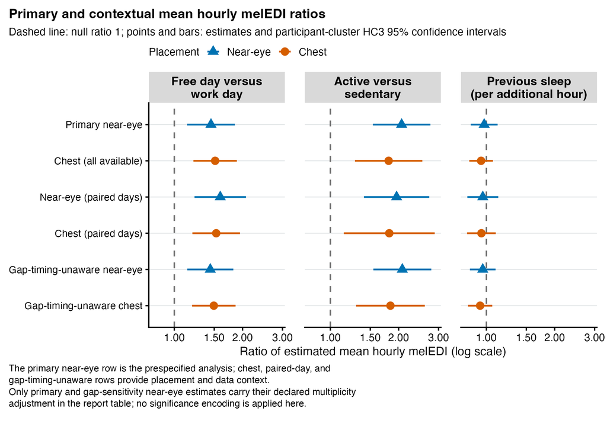

Figure 1: Estimated mean hourly melEDI among observed hours that met the support criteria. Points and bars are ratios and participant-cluster-robust 95% CIs; the dashed line is the null ratio of 1. Near-eye is the primary sensor position, and chest estimates are complementary non-ocular comparisons.

Source CSV

Table 1 gives the three primary common-effect tests.

Table 1: Primary near-eye associations.

| Predictor | Ratio (95% CI) | FDR-adjusted p |
| --- | --- | --- |
| Free day versus work day | 1.45 × (1.14–1.85) | **0.004** |
| Active versus sedentary | 2.06 × (1.54–2.76) | **<0.001** |
| Previous sleep duration (per hour) | 0.98 × (0.85–1.12) | 0.745 |

Directions are free versus work day, active versus sedentary day status, and the ratio per one additional hour of previous sleep. Participant-cluster-robust 95% CIs use HC3 with 137 participants. The three p-values form one FDR-adjusted family; the null ratio is 1.

Estimated mean hourly near-eye melEDI among observed hours that met the support criteria was 1.45 times as high on free as on work days (95% CI 1.14–1.85; FDR-adjusted p = 0.004) and 2.06 times as high on active as on sedentary days (1.54–2.76; FDR-adjusted p < 0.001). The ratio per one additional hour of previous sleep was 0.98 (0.85–1.12; FDR-adjusted p = 0.745). That interval allows a modest decrease or increase; it does not establish the absence of an association.

## Site dependence

The work/free association differed across study sites (FDR-adjusted p = 0.017). Activity and previous sleep had no FDR-retained predictor-by-site interaction. In the interaction model, the site-average work/free ratio, calculated with equal weight for each site, was 1.15 (95% CI 0.93–1.44), compared with 1.45 in the common-effect model. The interaction model’s site-average day-type association did not meet the adjusted threshold (three-predictor FDR-adjusted p = 0.298). Day type also did not meet the adjusted threshold when the working variance changed (FDR-adjusted p = 0.260). The day-type conclusion is therefore site- and model-dependent.

**Show site-specific estimates and interaction details**

### Site-specific estimates and interaction details

Table 2: Predictor-by-site interaction tests for the primary near-eye analysis.

| Predictor | Test | FDR-adjusted p |
| --- | --- | --- |
| Free day versus work day | F(8, 136) = 2.87 | **0.017** |
| Active versus sedentary | F(8, 136) = 1.01 | 0.644 |
| Previous sleep duration (per hour) | F(8, 136) = 0.45 | 0.887 |

The three predictor-by-site interaction blocks form one FDR-adjusted family. Only adjusted p-values at alpha = 0.050 are bolded.

The work/free association differed across sites (FDR-adjusted p = 0.017). Activity and previous sleep had no FDR-retained site interaction. The primary 1.45 work/free ratio comes from a model that constrains this association to be common across sites; it is not the average of the ratios from the interaction model. In the interaction model, the site-average ratio is the geometric mean of the nine site ratios: 1.15 (95% CI 0.93–1.44). Three sites are above that average and six are below it because three larger positive log-scale departures balance six smaller negative departures. This is not an algebraic inconsistency, but the attenuation from 1.45 to 1.15 shows that the work/free conclusion depends on model structure. The interaction-model site averages remain close to the common-effect results for activity (1.93 versus 2.06) and previous sleep (0.97 versus 0.98).

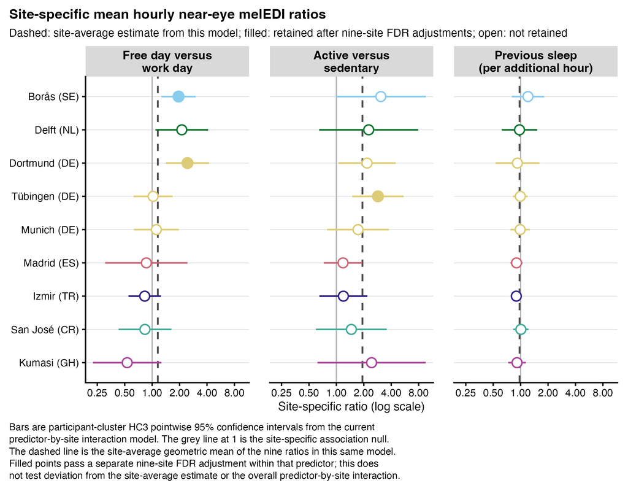

Figure 2: Site-specific estimates from the predictor-by-site interaction model. Filled and hollow points distinguish associations that did and did not meet alpha 0.050 after a separate nine-site FDR adjustment within each predictor. Pointwise 95% CIs are unadjusted; the dashed line is the site-average estimate, calculated with equal weight for each of the nine sites.

Source CSV

Table 3: Site-specific near-eye associations with separate nine-site FDR adjustments.

| Site | Reference Work day · sedentary · 7.8 h sleep | Free / Work | Active / Sedentary | Previous sleep / hour |
| --- | --- | --- | --- | --- |
| Site-average estimate predictor-by-site model | 89 lx (95% CI 67–119 lx) | 1.15× (95% CI 0.93–1.44) 3-predictor FDR p 0.298 103 lx (95% CI 77–138 lx) | **1.93× (95% CI 1.42–2.63)** 3-predictor FDR p **<0.001** 172 lx (95% CI 145–205 lx) | 0.97× (95% CI 0.88–1.08) 3-predictor FDR p 0.613 87 lx (95% CI 63–119 lx) |
| **● Borås (SE)** | 110 lx (95% CI 49–245 lx) vs site average FDR p 0.738 | **1.95× (95% CI 1.26–3.01)** 9-site FDR p **0.013** 214 lx (95% CI 97–471 lx) | 3.08× (95% CI 0.98–9.61) 9-site FDR p 0.159 338 lx (95% CI 173–659 lx) | 1.20× (95% CI 0.80–1.81) 9-site FDR p 0.941 132 lx (95% CI 56–311 lx) |
| **● Delft (NL)** | 107 lx (95% CI 32–361 lx) vs site average FDR p 0.738 | 2.12× (95% CI 1.09–4.12) 9-site FDR p 0.083 227 lx (95% CI 69–745 lx) | 2.26× (95% CI 0.65–7.91) 9-site FDR p 0.300 243 lx (95% CI 148–398 lx) | 0.97× (95% CI 0.62–1.52) 9-site FDR p 0.953 104 lx (95% CI 26–424 lx) |
| **● Dortmund (DE)** | 120 lx (95% CI 73–195 lx) vs site average FDR p 0.738 | **2.44× (95% CI 1.42–4.22)** 9-site FDR p **0.013** 292 lx (95% CI 192–446 lx) | 2.17× (95% CI 1.05–4.48) 9-site FDR p 0.159 260 lx (95% CI 134–503 lx) | 0.92× (95% CI 0.53–1.60) 9-site FDR p 0.953 110 lx (95% CI 49–250 lx) |
| **● Tübingen (DE)** | 58 lx (95% CI 33–103 lx) vs site average FDR p 0.738 | 1.02× (95% CI 0.63–1.67) 9-site FDR p 0.924 60 lx (95% CI 36–98 lx) | **2.86× (95% CI 1.49–5.47)** 9-site FDR p **0.015** 167 lx (95% CI 101–276 lx) | 0.99× (95% CI 0.82–1.20) 9-site FDR p 0.953 58 lx (95% CI 32–104 lx) |
| **● Munich (DE)** | 109 lx (95% CI 42–285 lx) vs site average FDR p 0.738 | 1.11× (95% CI 0.63–1.96) 9-site FDR p 0.879 121 lx (95% CI 48–305 lx) | 1.73× (95% CI 0.79–3.78) 9-site FDR p 0.300 189 lx (95% CI 122–292 lx) | 0.99× (95% CI 0.77–1.26) 9-site FDR p 0.953 108 lx (95% CI 43–269 lx) |
| **● Madrid (ES)** | 112 lx (95% CI 87–145 lx) vs site average FDR p 0.738 | 0.86× (95% CI 0.30–2.45) 9-site FDR p 0.879 97 lx (95% CI 39–240 lx) | 1.18× (95% CI 0.73–1.93) 9-site FDR p 0.560 133 lx (95% CI 88–200 lx) | 0.90× (95% CI 0.77–1.05) 9-site FDR p 0.813 101 lx (95% CI 70–146 lx) |
| **● Izmir (TR)** | 96 lx (95% CI 67–137 lx) vs site average FDR p 0.738 | 0.83× (95% CI 0.55–1.25) 9-site FDR p 0.659 80 lx (95% CI 54–118 lx) | 1.19× (95% CI 0.65–2.19) 9-site FDR p 0.565 115 lx (95% CI 65–202 lx) | 0.90× (95% CI 0.81–0.99) 9-site FDR p 0.299 86 lx (95% CI 59–127 lx) |
| **● San José (CR)** | 68 lx (95% CI 28–162 lx) vs site average FDR p 0.738 | 0.83× (95% CI 0.43–1.63) 9-site FDR p 0.879 56 lx (95% CI 19–165 lx) | 1.46× (95% CI 0.60–3.57) 9-site FDR p 0.521 99 lx (95% CI 61–159 lx) | 1.01× (95% CI 0.83–1.22) 9-site FDR p 0.953 68 lx (95% CI 24–195 lx) |
| **● Kumasi (GH)** | 53 lx (95% CI 12–236 lx) vs site average FDR p 0.738 | 0.53× (95% CI 0.22–1.26) 9-site FDR p 0.341 28 lx (95% CI 8–97 lx) | 2.44× (95% CI 0.62–9.56) 9-site FDR p 0.300 130 lx (95% CI 87–193 lx) | 0.91× (95% CI 0.73–1.14) 9-site FDR p 0.941 49 lx (95% CI 11–208 lx) |

The reference is a work day with sedentary status and 7.8 h previous sleep, the participant-day mean in the fitted sample. Reference and comparison melEDI values are response-scale point predictions in lx. The final lx line in each effect cell is the comparison condition: free day, active status, or one additional hour of previous sleep. All displayed 95% CIs use participant-cluster HC3. The blue-grey row gives site-average estimates from the same predictor-by-site interaction model and adjusts its three predictor contrasts together. Site-ratio tests use three separate nine-site FDR adjustments, one per predictor. Reference-profile site effects use a fourth nine-site FDR adjustment against the site-average reference. Only adjusted p-values are shown. Bold ratios meet alpha = 0.050 against ratio 1; these are not site-to-average or between-site tests. Bold site labels and filled site-colour circles identify the study sites; circle fill does not encode significance. The reference-column adjusted p-values show the separate reference-profile site-to-average tests.

Site-specific results CSV

Site-to-average deviation source CSV

## Sensitivity and complementary sensor evidence

The required **gap-timing-unaware dataset** uses the same 50%-per-hour and 80%-per-day coverage rules as the primary dataset, but does not use the timing of the remaining within-hour and within-day gaps for a metric-specific adjustment. The primary analysis could therefore be interpreted as time-sensitive. The near-eye estimates were stable under this dataset change, including on exact common hours. Complementary chest estimates had similar directions.

The paired-day comparison used the same 109 participants and 553 participant-days at both sensor positions, but three hourly keys differed at each position. It is not an observation-level identity comparison, an equivalence analysis, or a direct sensor-position effect. Activity and previous-sleep conclusions were stable across the declared checks. Day type remained sensitive to the working variance and to omission of some sites.

A separate near-eye-only sensitivity excluded participants recorded as not employed or marginally employed. It retained all nine sites and classified all three primary associations as stable within model uncertainty.

**Show complementary placement and sensitivity results**

### Required dataset sensitivity

The gap-timing-unaware sensitivity applies the comparison defined above to the same three predictors and sensor positions.

The all-available near-eye comparison contains 16,329 hours from 702 participant-days, 137 participants, and nine sites. On the exact common-hour frame, 16,329 hour keys remain and only 12 response values differ. The three near-eye ratios are stable: 1.44 for free/work, 2.08 for active/sedentary, and 0.96 per additional hour of sleep. The work/free site interaction also remains FDR-retained (FDR-adjusted p = 0.015).

Table 4: Primary and gap-sensitivity estimates on all available and exact common hours.

| Predictor | Primary | Gap sensitivity |
| --- | --- | --- |
| All available |  |  |
| Free day versus work day | 1.45 × (1.14–1.85) | 1.44 × (1.14–1.82) |
| Active versus sedentary | 2.06 × (1.54–2.76) | 2.08 × (1.55–2.79) |
| Previous sleep duration (per hour) | 0.98 × (0.85–1.12) | 0.96 × (0.85–1.10) |
| Exact common hours |  |  |
| Free day versus work day | 1.44 × (1.14–1.81) | 1.44 × (1.14–1.82) |
| Active versus sedentary | 2.06 × (1.54–2.76) | 2.08 × (1.55–2.79) |
| Previous sleep duration (per hour) | 0.96 × (0.85–1.09) | 0.96 × (0.85–1.10) |

Exact-common models use identical hour keys.

### Employment-eligibility sensitivity (near-eye only)

This sensitivity excluded six participants recorded as not employed or marginally employed. Students and trainees were retained, and age above 65 years was not an exclusion criterion. The restricted sample contained 15,871 supported hours from 684 participant-days and 131 participants at all nine sites, compared with 16,596 hours, 715 participant-days, and 137 participants in the primary near-eye sample. The same additive and predictor-by-site models, participant-cluster HC3 inference, and three-test false-discovery-rate families were used.

Table 5: Near-eye associations before and after the employment-eligibility restriction.

| Predictor | Primary | Employment eligible | Employment-eligible FDR-adjusted p | Stability |
| --- | --- | --- | --- | --- |
| Free day versus work day | 1.45 × (1.14–1.85) | 1.46 × (1.11–1.91) | **0.010** | Stable within model uncertainty |
| Active versus sedentary | 2.06 × (1.54–2.76) | 1.88 × (1.42–2.48) | **<0.001** | Stable within model uncertainty |
| Previous sleep duration (per hour) | 0.98 × (0.85–1.12) | 0.95 × (0.83–1.09) | 0.437 | Stable within model uncertainty |

Ratios compare free with work days, active with sedentary days, and one additional hour of previous sleep. The three employment-eligible p-values form one FDR-adjusted family; the null ratio is 1.

The restricted estimates were 1.46 for free versus work days (95% CI 1.11–1.91; **FDR-adjusted p = 0.010**), 1.88 for active versus sedentary days (1.42–2.48; **FDR-adjusted p < 0.001**), and 0.95 per additional hour of previous sleep (0.83–1.09; FDR-adjusted p = 0.437). Day-type heterogeneity across sites also remained supported, F(8, 130) = 3.59 (**FDR-adjusted p = 0.003**); activity and previous-sleep heterogeneity remained unsupported. Both restricted fits passed the stored numerical checks. The existing residual mean-variance, calibration, and temporal-correlation qualifications remain.

Sample-flow CSV · association-comparison CSV · site-heterogeneity CSV

### Complementary chest and paired-day results

The all-available chest ratios are 1.51 (95% CI 1.21–1.89), 1.81 (1.28–2.54), and 0.95 (0.84–1.07) for free/work, active/sedentary, and sleep, respectively. Chest is a complementary non-ocular sensor position. The paired-day comparison uses the same 109 participants and 553 participant-days at both sensor positions. Near-eye ratios are 1.59, 1.96, and 0.96; chest ratios are 1.53, 1.82, and 0.95. Each frame contains 12,842 participant-hours, but three hourly keys differ at each sensor position. An observation-level identity scatter is therefore not valid, and similar directions do not show equivalence or estimate a direct sensor-position effect.

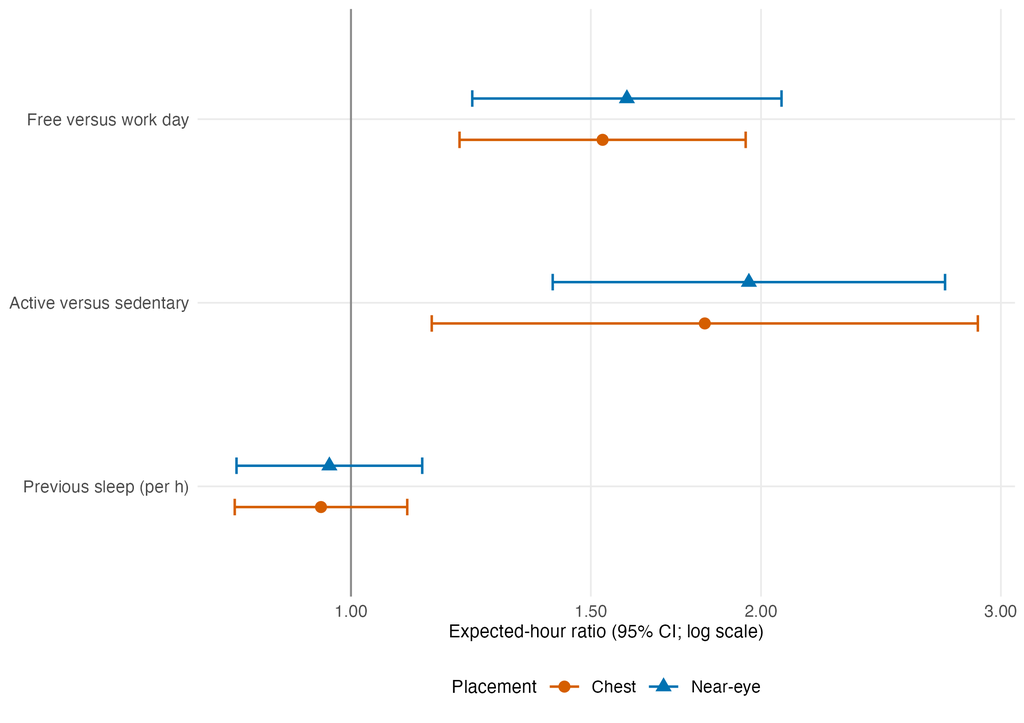

Figure 3: Near-eye and complementary chest estimates for the same participants and participant-days. Three hourly keys differ at each sensor position, so an observation-level identity scatter is not valid.

Source CSV

### Working-variance and influence sensitivity analyses

Changing the working variance from power 1 to fixed power 1.8 changes the work/free estimate to 1.15 (95% CI 0.91–1.45; FDR-adjusted p = 0.260). Activity remains 1.91 (1.49–2.45; FDR-adjusted p < 0.001), and sleep is 0.95 (0.88–1.04; FDR-adjusted p = 0.260). Changing the participant-cluster small-sample correction from HC3 to HC1 or HC2 changes uncertainty only slightly. Giving each site equal weight or weighting sites by the observed sample gives the same common-effect estimates. Replacing diary-defined day type with weekday/weekend gives 1.23 (0.92–1.66) for weekend versus weekday and has no new p-value family.

Table 6: Selected declared sensitivities for the three primary predictors.

| Predictor | Reference | Alternative | Classification |
| --- | --- | --- | --- |
| Quasi-Poisson vs p = 1.8 |  |  |  |
| Free day versus work day | 1.45 × (1.14–1.85) | 1.15 × (0.91–1.45) | Multiplicity-Conclusion-Sensitive |
| Active versus sedentary | 2.06 × (1.54–2.76) | 1.91 × (1.49–2.45) | Stable Within Model Uncertainty |
| Previous sleep duration (per hour) | 0.98 × (0.85–1.12) | 0.95 × (0.88–1.04) | Stable Within Model Uncertainty |
| HC3 vs HC1 |  |  |  |
| Free day versus work day | 1.45 × (1.14–1.85) | 1.45 × (1.14–1.84) | Stable Within Model Uncertainty |
| Active versus sedentary | 2.06 × (1.54–2.76) | 2.06 × (1.55–2.74) | Stable Within Model Uncertainty |
| Previous sleep duration (per hour) | 0.98 × (0.85–1.12) | 0.98 × (0.86–1.11) | Stable Within Model Uncertainty |
| HC3 vs HC2 |  |  |  |
| Free day versus work day | 1.45 × (1.14–1.85) | 1.45 × (1.14–1.84) | Stable Within Model Uncertainty |
| Active versus sedentary | 2.06 × (1.54–2.76) | 2.06 × (1.55–2.75) | Stable Within Model Uncertainty |
| Previous sleep duration (per hour) | 0.98 × (0.85–1.12) | 0.98 × (0.86–1.11) | Stable Within Model Uncertainty |
| Site-average weighting compared with observed-site weighting |  |  |  |
| Free day versus work day | 1.45 × (1.14–1.85) | 1.45 × (1.14–1.85) | Stable Within Model Uncertainty |
| Active versus sedentary | 2.06 × (1.54–2.76) | 2.06 × (1.54–2.76) | Stable Within Model Uncertainty |
| Previous sleep duration (per hour) | 0.98 × (0.85–1.12) | 0.98 × (0.85–1.12) | Stable Within Model Uncertainty |

Seven score-ranked participants and all nine sites were deleted one at a time; all 16 refit sets passed the numerical model checks. Activity intervals exclude one in all 16 checks, and sleep intervals do so in none. Work/free intervals exclude one after all seven participant deletions but only seven of nine site deletions: omitting Dortmund (DE) gives 1.26 (0.98–1.62), and omitting Borås (SE) gives 1.34 (0.99–1.80).

Table 7: Targeted participant and site deletion checks.

| Type | Predictor | Largest shift (HC3 SE) | CIs excluding 1 |
| --- | --- | --- | --- |
| Participant deletion | Active versus sedentary | 0.487 | 7/7 |
| Participant deletion | Previous sleep duration (per hour) | 0.589 | 0/7 |
| Participant deletion | Free day versus work day | 0.532 | 7/7 |
| Site deletion | Active versus sedentary | 0.612 | 9/9 |
| Site deletion | Previous sleep duration (per hour) | 0.441 | 0/9 |
| Site deletion | Free day versus work day | 1.146 | 7/9 |

## Model-check qualification

All common-effect and predictor-by-site interaction fits met the stored numerical checks. The primary response nevertheless has substantial dispersion, imperfect fitted-decile calibration, increasing residual spread, and residual correlation across nearby hours. Participant-cluster HC3 supports the reported uncertainty but does not remove those patterns or repair the mean structure.

**Show detailed model checks and influence analyses**

### Detailed model checks and influence analyses

All stored additive and full fits converge, have full-rank fixed-effect designs, and have finite, positive-definite unmodified HC3 covariance matrices. These checks establish numerical estimability, not adequate fit.

Table 8: Model checks for the six common-effect mean models.

| Scenario | Zero hours | Dispersion | Observed/fitted decile range | Residual–fitted Spearman | \|Residual\|–fitted Spearman | Residual lag 1 | Residual lag 6 | Checks |
| --- | --- | --- | --- | --- | --- | --- | --- | --- |
| Primary near-eye | 28.3% | 3,617.867 | 0.78–1.61 | −0.564 | 0.553 | 0.464 | 0.013 | Meets numerical checks |
| Chest, all available | 29.1% | 4,471.413 | 0.68–1.49 | −0.605 | 0.585 | 0.366 | −0.006 | Meets numerical checks |
| Near-eye, paired days | 29.1% | 3,837.745 | 0.65–1.62 | −0.590 | 0.568 | 0.463 | 0.011 | Meets numerical checks |
| Chest, paired days | 29.6% | 4,872.968 | 0.70–1.81 | −0.636 | 0.612 | 0.376 | −0.007 | Meets numerical checks |
| Gap sensitivity, near-eye | 28.3% | 3,727.388 | 0.77–1.52 | −0.563 | 0.551 | 0.461 | 0.013 | Meets numerical checks |
| Gap sensitivity, chest | 29.1% | 4,562.913 | 0.66–1.44 | −0.608 | 0.587 | 0.363 | −0.008 | Meets numerical checks |

Calibration is in-sample and descriptive. Dispersion is the Pearson working-dispersion estimate.

The primary response contains 28.3% exact-zero hours and has working dispersion 3,618. Fitted-decile observed/fitted ratios range from 0.78 to 1.61. Residual–fitted Spearman correlation is -0.564, and absolute residual–fitted correlation is 0.553. Residual correlation is 0.464 at lag 1, 0.233 at lag 2, and 0.013 at lag 6. Participant-cluster HC3 accommodates within-participant dependence for uncertainty but does not whiten residuals or repair the mean structure. The residual-clock display shows remaining daytime structure.

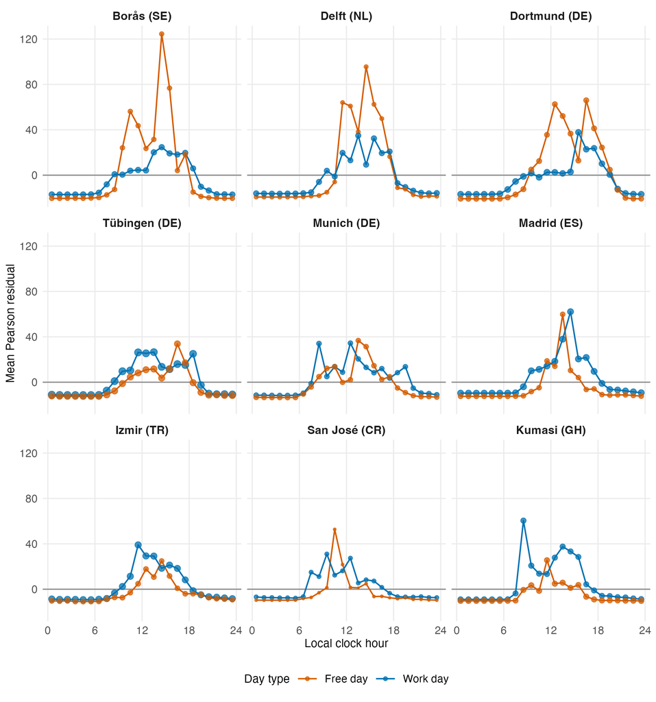

Source CSV

## Exploratory diary and clock-time analyses

Exercise location, active travel, sedentary time, sleep onset, and final wake time are descriptive extensions fitted one at a time. They do not select or rescue the primary model. The nonlinear generalized additive model (GAM) analysis allows the association with local clock time to bend across the day and is separate from the primary average associations. Its pointwise 95% CI applies to one displayed time. It is not a simultaneous band or a multiplicity-controlled whole-curve test.

Active status was higher from about 07:15 to 19:00 and lower from about 23:30 to 05:15 across midnight, when estimated melEDI was low. The free-day curve was lower from about 06:45 to 09:15 and from 18:45 to 19:15. These windows exclude the null ratio 1 on the local 15-minute grid, but they do not define confirmatory significant time segments.

**Show exploratory clock-time and diary analyses**

### Detailed exploratory analyses

### Additional diary measures

Exercise location, active travel, sedentary time, sleep onset, and final wake time were fitted one at a time on their own exact samples. They are descriptive extensions, have 95% CIs but no confirmatory p-values, and do not select or rescue the primary model.

Table 9: Exploratory one-at-a-time diary associations.

| Effect | Ratio (95% CI) |
| --- | --- |
| Exercise indoors vs outdoors | 0.49 × (0.34–0.70) |
| Both locations vs outdoors | 0.77 × (0.37–1.62) |
| Active travel, per hour | 1.10 × (0.97–1.26) |
| Sedentary time, per hour | 0.98 × (0.93–1.03) |
| Sleep onset, per hour later | 0.87 × (0.73–1.05) |
| Wake time, per hour later | 0.87 × (0.73–1.05) |

Exploratory quasi-Poisson log means with participant-cluster HC3. No p-values are calculated or displayed.

### Nonlinear time-of-day GAM analysis

The exploratory nonlinear generalized additive model (GAM) analysis allows the associations with local clock time to bend across the day. It separates occurrence (melEDI greater than zero, binomial-logit) from positive magnitude (Gamma-log); multiplying their response-scale means gives estimated hourly melEDI. Both components use four cyclic factor-by clock smooths for work/free day × activity status, with one smoothing parameter shared across the four curves. Study site enters as a fixed adjustment only; there is no site-specific clock smooth and no `sz` component. Participant and participant-day random-effect smooths, true-sequence `AR.start`, and residual working correlations remain. The chosen basis is `k = 16`, fitted with `bam(method = "fREML", discrete = TRUE)`.

```r
two_part_formula_registry |>
  dplyr::select(
    Component = .data$component,
    Family = .data$response_family,
    `Evaluated Wilkinson formula` = .data$selected_formula,
    Method = .data$method,
    Discrete = .data$discrete,
    `Basis k` = .data$selected_basis_k
  ) |>
  compact_gt(
    source_note = paste0(
      "Exploratory only. Positive-magnitude sequences are rebuilt after ",
      "zero hours are removed."
    )
  )
```

Table 10: Exploratory two-part formulas.

| Component | Family | Evaluated Wilkinson formula | Method | Discrete | Basis k |
| --- | --- | --- | --- | --- | --- |
| occurrence | Binomial occurrence with logit link | melEDI_positive ~ previous_sleep_duration_centered_h + site + work_free_day * activity_status + s(clock_hour, by = day_activity_group, bs = "cc", k = 16, id = 1) + s(participant_key, bs = "re") + s(pa… | fREML | TRUE | 16 |
| positive_magnitude | Gamma positive magnitude with log link | response_value ~ previous_sleep_duration_centered_h + site + work_free_day * activity_status + s(clock_hour, by = day_activity_group, bs = "cc", k = 16, id = 1) + s(participant_key, bs = "re") + s(par… | fREML | TRUE | 16 |

Exploratory only. Positive-magnitude sequences are rebuilt after zero hours are removed.

The occurrence and positive-magnitude models converge with full-rank fixed-smooth designs. Their residual working correlations are 0.418 and 0.440. Occurrence calibration overpredicts the lowest fitted-probability decile (observed/fitted ratio 0.829); positive-magnitude calibration ranges from about 0.89 to 1.21. The four occurrence smooths have `k`-check p-values 0.013–0.023, although their edf remain below the basis ceiling; this is a residual model-structure warning. Positive-magnitude `k`-check p-values are 0.18–0.21. Moving from `k = 12` to `k = 16` changes the combined curves by 15.1% at the 95th percentile, so the curves provide timing context rather than confirmatory whole-curve tests.

#### Reader displays and temporal contrasts

Each figure has three aligned parts: (A) expected curves, (B) the corresponding complete response-scale ratio with a null reference of one, and (C) participant-hour support. The contrast panels are derived from the fitted two-part models without refitting; they compare complete estimated melEDI rather than one smooth term. Free day is divided by work day after equal weighting over activity status and the nine sites. Active is divided by sedentary after equal weighting over work/free day and the nine sites.

The expected-value panels use a symmetric logarithmic, or symlog, display that is linear from 0 to 1 lx and logarithmic above 1 lx. Tick labels remain in lux.

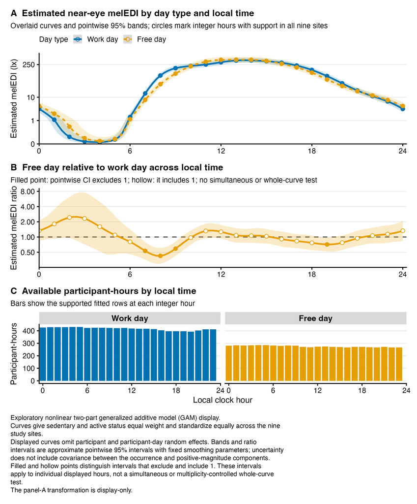

Figure 5: Exploratory nonlinear day-type timing display: overlaid estimated curves, the complete response-scale free-day/work-day contrast, and participant-hour support. The other binary factor and all nine sites receive equal weight. A pointwise 95% CI applies at one displayed hour, not to the whole curve. Filled and hollow points distinguish intervals that exclude and include the null ratio of 1; this is not a multiplicity-controlled or simultaneous whole-curve test.

Curve source CSV · Ratio source CSV · Support source CSV

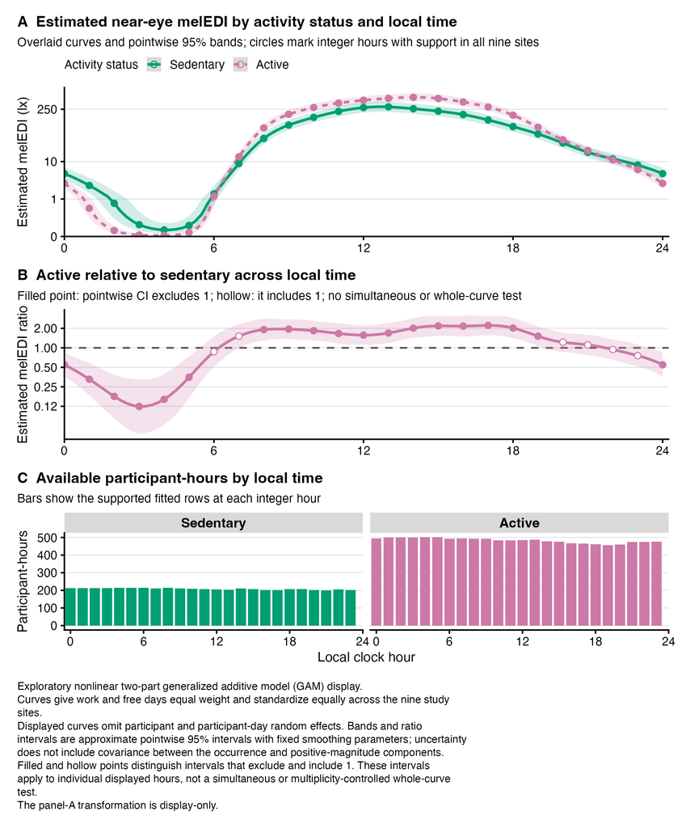

Figure 6: Exploratory nonlinear activity timing display: overlaid estimated curves, the complete response-scale active/sedentary contrast, and participant-hour support. Work and free days and all nine sites receive equal weight. A pointwise 95% CI applies at one displayed hour, not to the whole curve. Filled and hollow points distinguish intervals that exclude and include the null ratio of 1; this is not a multiplicity-controlled or simultaneous whole-curve test.

Curve source CSV · Ratio source CSV · Support source CSV

The paired prediction gradients retain covariance between numerator and denominator within each component. The interval calculation treats smoothing parameters as fixed and sets cross-component occurrence–magnitude covariance to zero. It also inherits the residual working-correlation, occurrence calibration, and basis-sensitivity limitations above. Overnight ratios and intervals widen where numerator and denominator expectations approach zero. No time segment is labelled significant, and no global or simultaneous whole-curve inference is made.

## Interpretation and limitations

The common-effect results describe observational associations with estimated mean hourly near-eye melEDI among observed hours that met the support criteria. They do not establish causal effects and do not answer the broader preregistered question about daily light-exposure metrics. Participant-days with more retained participant-hours contribute more weight.

The free/work result is qualified by its predictor-by-site interaction, the smaller site-average estimate from that interaction model, the alternative working-variance result, and leave-one-site-out checks. Chest and paired-day analyses provide complementary non-ocular context, not sensor-position equivalence or a direct placement effect. Participant-cluster-robust inference allows within-participant dependence, but it does not remove residual time-of-day structure or repair an imperfect mean model. The nonlinear GAM analysis is exploratory; its pointwise intervals apply to individual displayed hours and do not support simultaneous whole-curve claims.

## Preregistration deviations

- `DEV-015` records the documented hourly geometric-mean melEDI estimand rather than the preregistered daily metric set.
- `DEV-030` limits the primary family to day type, active/sedentary status, and previous-night sleep duration.
- `DEV-031` records the zero-inclusive quasi-Poisson common-effect model, participant-cluster HC3 inference, predictor-by-site interactions, and separate exploratory nonlinear clock-time analysis.
- `DEV-032` records the separate FDR families and the distinction between average associations, predictor-by-site interactions, and exploratory site screens.

## Detailed analysis record

This section retains the exact fitted samples, model formulas, declared FDR families, linked source data, and technical provenance for auditing.

### Outcome, predictors, sensor positions, and fitted samples

The primary outcome is the zero-aware geometric mean melEDI for each retained participant-hour at the near-eye sensor position. A participant-hour is one observed one-hour interval from one participant that met the support criteria defined in Preparation 06. Activity is binary: sedentary means no reported exercise, while active includes light, moderate, or vigorous reported exercise. Day type and activity are participant-day diary variables, where a participant-day is one calendar day contributed by one participant; previous sleep duration is linked from the preceding sleep period. Because participant-days contribute 19–24 supported participant-hours, the estimand is participant-hour weighted rather than participant-day weighted.

Table 11: Exact fitted samples for the six core H06 analyses.

| Scenario | Hours | Participant-days | Participants | Sites | Supported hours/day |
| --- | --- | --- | --- | --- | --- |
| Primary near-eye | 16,596 | 715 | 137 | 9 | 19–24 |
| Chest, all available | 18,352 | 789 | 149 | 8 | 19–24 |
| Near-eye, paired days | 12,842 | 553 | 109 | 8 | 19–24 |
| Chest, paired days | 12,842 | 553 | 109 | 8 | 19–24 |
| Gap sensitivity, near-eye | 16,329 | 702 | 137 | 9 | 20–24 |
| Gap sensitivity, chest | 18,112 | 777 | 149 | 8 | 20–24 |

All rows are exact fitted samples. The complete site × category registry is available below.

The primary fit contains 16,596 supported hours from 715 participant-days, 137 participants, and nine study sites. The smallest primary site × category cells contain 185 hours, 8 participant-days, and 4 participants; these minima do not all occur in the same cell. Download the exact category cell registry.

The TUM exercise-diary identity check uses the pinned immutable `melidosData` 1.0.6 object and finds 7 S001 rows and 0 S101 rows, with no local identifier rewrite. The `KNUST_S005` numeral 3,600 is interpreted as 3,600 seconds, or one sedentary hour, only for eligible exploratory analyses; it is not added to the primary analysis.

For the required sensitivity analysis, the **gap-timing-unaware dataset** applies the same 50%-per-hour and 80%-per-day coverage rules but does not use the timing of remaining missing observations for a metric-specific adjustment. The primary analysis could therefore be interpreted as time-sensitive. Both datasets are defined in Preparation 06. Hereafter, the corrected input is called the **primary dataset**.

### Models and inference

The common-effect model is a zero-inclusive quasi-Poisson generalized linear model with a log link and fixed study-site terms. A participant-cluster-robust 95% confidence interval (95% CI) allows observations from the same participant to be related and uses the HC3 small-sample correction. Participants, rather than participant-hours, are therefore the inferential replicates. One-coefficient tests use a *t* reference with 136 degrees of freedom.

The predictor-by-site interaction model allows the association of day type, activity, or previous sleep with hourly melEDI to differ by study site. Its site-interaction blocks use Wald *F* tests with restriction-rank and 136 denominator degrees of freedom. A site-average estimate averages across the nine sites with equal weight for each site on the linear-predictor scale before back-transformation.

```r
formula_text <- function(x) paste(deparse(x), collapse = " ")
selected_formulas <- h06_formula_set()[c("additive", "full")]

tibble::enframe(
  selected_formulas,
  name = "model_id",
  value = "formula"
) |>
  dplyr::mutate(
    Role = dplyr::recode(
      .data$model_id,
      additive = "Primary population-mean associations",
      full = "Predictor-by-site interaction blocks"
    ),
    `Evaluated Wilkinson formula` = vapply(
      .data$formula,
      formula_text,
      character(1)
    )
  ) |>
  dplyr::select(Model = .data$model_id, .data$Role,
                .data$`Evaluated Wilkinson formula`) |>
  compact_gt(
    source_note = paste0(
      "All comparisons use the same prepared rows. Quasi-likelihood AIC and ",
      "likelihood-ratio tests are not reported."
    )
  )
```

Table 12: Exact evaluated Wilkinson formulas.

| Model | Role | Evaluated Wilkinson formula |
| --- | --- | --- |
| additive | Primary population-mean associations | response_value ~ site + work_free_day + activity_status + previous_sleep_duration_centered_h |
| full | Predictor-by-site interaction blocks | response_value ~ site * work_free_day + site * activity_status + site * previous_sleep_duration_centered_h |

All comparisons use the same prepared rows. Quasi-likelihood AIC and likelihood-ratio tests are not reported.

False-discovery-rate (FDR) adjustment is applied separately to the three primary association tests, the three site-interaction tests, and the three practical contrasts. Only FDR-adjusted p-values are displayed. The exploratory site-specific screen uses three additional, separate nine-site FDR adjustments, one within each predictor. Chest, paired-position, weekday/weekend, influence, and other exploratory outputs do not create post hoc p-value families.

Table 13: Declared sets of tests and FDR adjustment.

| Set of tests | Tests | Adjustment |
| --- | --- | --- |
| Primary near-eye main-association tests | 3 | FDR |
| Primary near-eye site-heterogeneity tests | 3 | FDR |
| Primary equal-site practical contrasts | 3 | FDR |
| Gap-timing-unaware near-eye main tests | 3 | FDR |
| Gap-timing-unaware near-eye heterogeneity tests | 3 | FDR |

**Show technical source and figure checks**

### Technical source and figure checks

### Figure reproducibility

All six reader-facing figures were assessed at 170 mm on an A4 portrait page with 20-mm side margins. Native and intended widths are equal, and the smallest essential text remains 7.5 pt. Physical-size inspection found no clipping, overlap, harmful wrapping, distortion, or materially imbalanced data region. Every figure has accessible alt text and linked source data.

Table 14: Physical-size checks for all reader-facing H06 figures.

| Figure | Native width (mm) | Intended width (mm) | Scale factor | Smallest nominal text (pt) | Effective final text (pt) | Status |
| --- | --- | --- | --- | --- | --- | --- |
| H06_primary_residual_clock | 170 | 170 | 1 | 8.0 | 8.0 | Verified |
| H06_paired_placement_effects | 170 | 170 | 1 | 8.0 | 8.0 | Verified |
| H06_reader_primary_effects | 170 | 170 | 1 | 7.5 | 7.5 | Verified |
| H06_reader_temporal_day_type | 170 | 170 | 1 | 7.5 | 7.5 | Verified |
| H06_reader_temporal_activity | 170 | 170 | 1 | 7.5 | 7.5 | Verified |
| H06_stage3_site_specific_significance_screen | 170 | 170 | 1 | 8.0 | 8.0 | Verified |

The analysis used R 4.6.1 and the project library. Scientific transformations, model fits, model checks, contrasts, tables, and figures are implemented in H06-scoped R scripts. The temporal contrasts use the stored model objects and did not refit a GAM. No bootstrap was required, no package was installed, and no shared input was edited.

How the hourly H06 analysis was prepared provides the data, model, model-check, sensitivity, source-data, and file-identity record for these results.